# Processo Empreendedor e Criação de Novos Negócios

Empreendedorismo Tecnológico e Desenvolvimento Territorial · Aula 07

Prof. Dr. Luiz Diego Vidal Santos

## Unidade II Visão Geral da Aula

Roteiro da aula · 4 horas Tópicos estruturantes

1. O campo científico do empreendedorismo (Shane & Venkataraman, 2000).
2. *Causation* vs. *Effectuation* (Sarasvathy, 2001).
3. *Bricolagem* empreendedora em contextos de escassez (Baker & Nelson, 2005).
4. Estágios de criação de novos negócios tecnológicos e “Vale da Morte”.
5. Equipes fundadoras e capital social no território.

Objetivo central Decisão sob incerteza

Examinar o **processo empreendedor** sob a ótica teórica contemporânea, contrapondo modelos preditivos (*causation*) a lógicas adaptativas (*effectuation* e bricolagem) na criação de novos negócios em ambientes de incerteza e restrição de recursos.

**Foco da Unidade II:** da teoria da oportunidade à execução prática em territórios com restrição de capital.

# O Nexo Indivíduo–Oportunidade

## Conceito O campo científico em Shane & Venkataraman (2000)

Fundamento epistemológico Definição do campo

- Empreendedorismo não é apenas “traço de personalidade” nem apenas “gestão de pequenas empresas”.
- É o estudo acadêmico de **como, por quem e com que efeitos** as oportunidades para criar novos bens e serviços são **descobertas, avaliadas e exploradas**.
- **Dois elementos inseparáveis:** a existência de **oportunidades lucrativas/de valor** e a presença de **indivíduos empreendedores** capazes de percebê-las e agir.

Formas organizacionais Modos de exploração da oportunidade

1. **Criação de uma nova firma** (foco clássico de *startups* e *spin-offs*).
2. **Venda/licenciamento da oportunidade** a firmas existentes (comum quando ativos complementares de manufatura e distribuição são caros).

**Questão Territorial:** em regiões com baixa densidade de grandes empresas locais, a criação de novas firmas exige maior suporte institucional inicial.

# Causation vs. Effectuation e Bricolagem

## Método Lógicas de decisão: Sarasvathy (2001) e Bricolagem

| Dimensão | *Causation* (Causal) | *Effectuation* (Efetual) |
| --- | --- | --- |
| **Ponto de partida** | Um objetivo/meta dado | Os **meios disponíveis** (*quem sou, o que sei, quem conheço*) |
| **Critério de decisão** | Retorno esperado máximo | **Perda aceitável** (*affordable loss*) |
| **Relação com atores** | Análise competitiva | **Alianças estratégicas** e pré-compromissos |
| **Visão de futuro** | Previsão (*predizer*) | **Controle** do imprevisível (*cocriar*) |
| **Contingências** | Evitar surpresas | Alavancar surpresas |

Baker & Nelson, 2005 Bricolagem empreendedora

- **“Fazer com o que está à mão”**: recombinar recursos subutilizados, locais ou descartados para resolver novos problemas.
- Extremamente relevante para empreendedores tecnológicos e sociais em **territórios periféricos** com escassez de *venture capital*.

*Causation* pressupõe mercados previsíveis; *Effectuation* e *Bricolagem* viabilizam ação sob incerteza knightiana e restrição de recursos.

## Síntese Esquema: Causation vs. Effectuation (Sarasvathy, 2001)

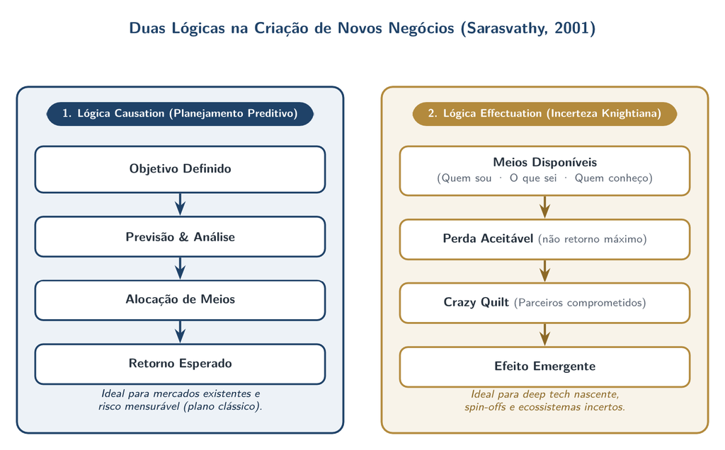

Comparação entre as lógicas Causation (planejamento preditivo) e Effectuation (meios disponíveis, perda aceitável e alianças).

Arquitetura decisória na criação de novos negócios (Sarasvathy, 2001) Da lógica preditiva baseada em metas à construção emergente com parceiros comprometidos

Em projetos de *deep tech* nascente e *spin-offs* acadêmicas, a lógica efetual reduz o risco de imobilizar recursos em planos rígidos antes da validação.

# Ciclo de Vida e “Vale da Morte”

## Território Da pesquisa ao mercado: etapas e capital social

Maturação TRL 1–9 Etapas do processo empreendedor

1. **Ideação e Descoberta:** pesquisa, observação de mercado ou problema territorial.
2. **Prova de Conceito e Prototipagem (TRL 1–4):** alto risco técnico; financiamento público e acadêmico.
3. **Validação e Tração Inicial (TRL 5–7):** **Vale da Morte** — recursos de pesquisa acabam antes de haver receita recorrente.
4. **Escala e Crescimento (TRL 8–9):** expansão comercial, padronização e governança corporativa.

Granovetter · Redes Equipes e capital social

- Negócios de base tecnológica raramente sobrevivem com fundador solo: exigem **complementaridade técnica + comercial/gestão**.
- **Laços fortes vs. laços fracos (Granovetter):** laços locais garantem confiança inicial; laços externos conectam o empreendimento a mercados e tecnologia de fronteira.

A travessia do **Vale da Morte** depende tanto de engenharia financeira quanto da densidade de laços institucionais e comerciais da equipe.

## Crítica O “Vale da Morte” tecnológico e o fluxo de caixa

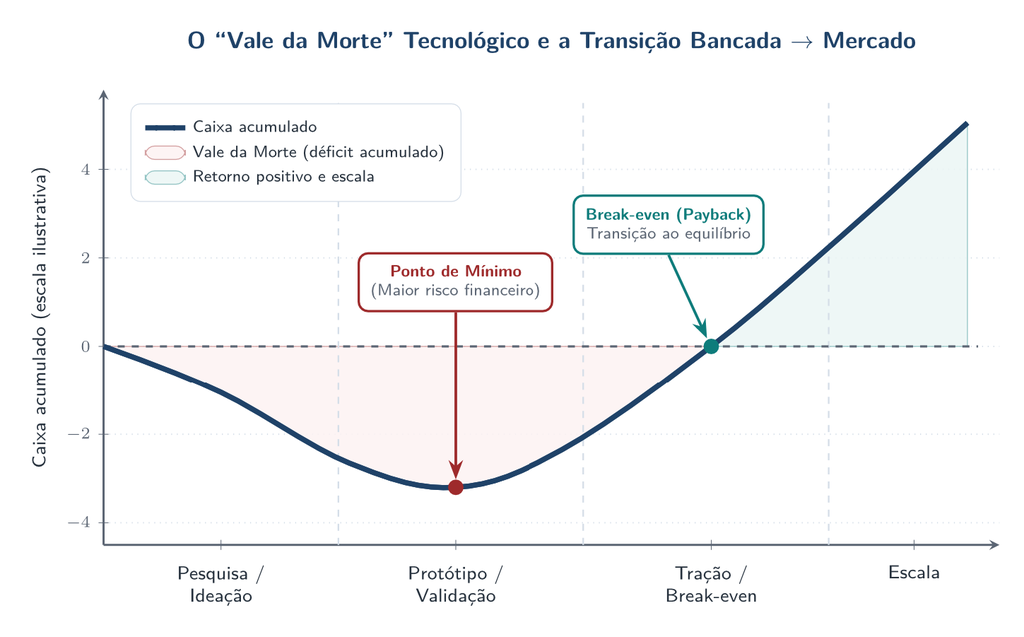

Curva de caixa acumulado ao longo dos estágios de pesquisa, prototipagem, tração e escala, destacando o Vale da Morte e o break-even.

Transição bancada → mercado e déficit acumulado de caixa Ponto de mínimo financeiro entre TRL 4–7 antes de atingir o equilíbrio operacional (break-even)

Sem subvenção pública (FINEP, FAPs), infraestrutura de incubação ou clientes-piloto, projetos promissores sucumbem no ponto de mínimo antes da escala.

# Oficina e Leituras

## Método Exercício: Inventário Efetual (35 min) e Leituras

**01 · Quem somos / O que sabemos:** mapeie as competências técnicas, laboratoriais e acadêmicas já disponíveis na equipe.

**02 · Quem conhecemos:** identifique redes locais mobilizáveis (universidades, cooperativas, prefeituras, empresas e ICTs).

**03 · Perda aceitável (60 dias):** defina o mínimo viável de recursos financeiros, horas e materiais para testar a ideia em campo.

Preparação · Aula 08 Leituras para a próxima aula

- **SHANE, S.** *Prior knowledge and the discovery of entrepreneurial opportunities*. Organization Science, 2000.
- **BARON, R. A.** *Opportunity recognition as pattern recognition*. AMP, 2006.
- **JUNGMANN, D. M.; BONETTI, E. A.** *A caminho da inovação* (IEL, 2010 — Caps. sobre PI).